# Homework 4: Functions and Tidy data

Quentin D’Arcy

10/6/2020

# Question 1: Write a function for a single bootstrap from a given vector

```r
#Create a single bootstrap
one_boot <- function(boot_vec){

  #Sample based on the boot_vec parameters
 boot_ret <-  sample(boot_vec, size = length(boot_vec), replace = TRUE)

 #return the value
 return(boot_ret)
}

#Prove it works
my_vec = c(1,2,3,4,5,6,7,8,9,10)
one_boot(my_vec)
```

```
##  [1] 5 5 1 2 4 1 3 1 6 8
```

# Question 2: Given a vector, a request for some number of bootstraps (R), and a sample statistic function, return R number of values of that statistic.

### Have R = 1000 the default and the function is mean. Show this works

```r
#Create the function with an input vector, an R number of bootstraps, and the statistical function
boot_mean <- function(bootData, R = 1000, stat_func = mean){

  #Find the "statistic" of each boot and replicate it R number of times
  stat_vec <- replicate(R, stat_func(one_boot(bootData)))

  #Return the mean_vec
  return(stat_vec)
}

#Get 10 bootstrapped replicate draws of a mean from some vector
ten_boot <- boot_mean(my_vec, R = 10)
ten_boot
```

```
##  [1] 5.8 5.4 6.5 6.5 6.6 6.1 5.9 6.4 6.9 4.8
```

It looks like these values seem reasonable given our starting vector (a 1:10 vector). Here is a comparison between the mean of the 10 bootstrapped means and the mean of our starting vector:

**Ten bootstrap mean** : 6.09

**Mean of our starting vector**: 5.5

Based on this the bootstrapped means seem reasonable

# Question 3: Given a vector, a request for some number of bootstraps, and a sample statistic function, return:

### 1) The original value of the statistic as applied to the vector

### 2) The mean of the statistic generated by the bootstrapped reps

### 3) The Upper/Lower 95% CI of the bootstrapped statistic (.025 and .975 quantile)

### 4) The bias (the original value of the statistic - the mean of the bootstrapped statistic)

Here I’ll be using mean as my sample statistic

```r
#Create a function that accepts a vector, num of bootstraps, and a statistical function
analyze_data <- function(data_vec, boot_num = 1000, stat_func = mean){

  #Get the original mean
  original_stat <- stat_func(data_vec)

  #Get the bootstrapped mean
  strap_stat <- (boot_mean(data_vec,boot_num, stat_func))

  #Get the upper/lower 95% CI of the strap_mean
  upper_ci <- quantile(strap_stat, probs = .975)
  lower_ci <- quantile(strap_stat, probs = .025)

  #The bias
  data_bias <- original_stat - mean(strap_stat)

  #combine them in to a single return vector
  master_data = c(original_stat, stat_func(strap_stat), upper_ci, lower_ci, data_bias)

  #return that
  return(master_data)
}

fun_check <- analyze_data(my_vec, boot_num = 10)
fun_check
```

```
##                   97.5%    2.5%
##  5.5000  5.6400  6.7875  4.3575 -0.1400
```

So, here is our data! (Again, using mean as our chosen statistic)

**Mean of the original data** : 5.5

**Mean of the bootstrapped means** : 5.64

**Upper 95% Confidence Interval of the bootstraps** : 6.7875

**Lower 95% Confidence Interval of the bootstraps** : 4.3575

**The Bias** : -0.14

# Set 4: FiveThirtyEight Poll data

### 4a) Download and look at the data

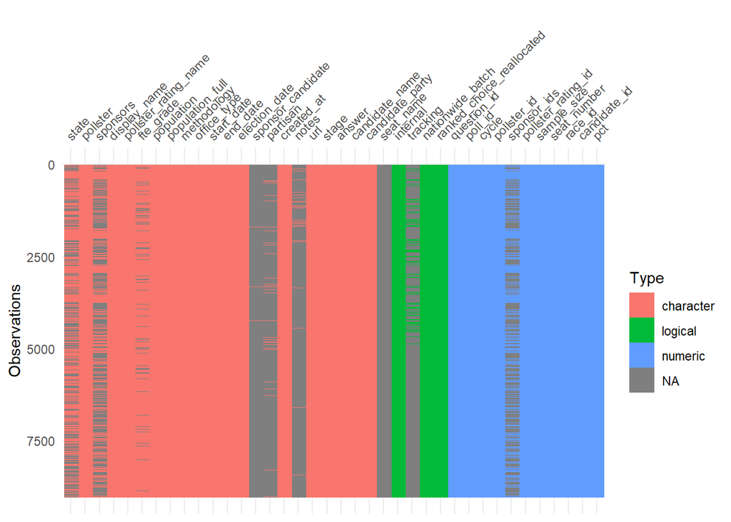

```r
#here for good practice
setwd(here::here())

#load our readr library
library(readr)

#read the .csv file with poll data
poll_data <- read_csv("data/president_polls.csv")
#View that data
library(visdat)
vis_dat(poll_data)
```

Here we can see this data is in Long format

### 4b) Get just the polling data for the week 9/29 to today

```r
#load lubridate
library(lubridate)
#Find the polling data in question using lubridate
recent_poll <- poll_data %>%
  filter(answer %in% c('Trump', 'Biden'), mdy(start_date) >= mdy("9/29/20"))

#Check the new df
head(recent_poll)
```

```
## # A tibble: 6 x 38
##   question_id poll_id cycle state pollster_id pollster sponsor_ids sponsors
##         <dbl>   <dbl> <dbl> <chr>       <dbl> <chr>          <dbl> <chr>
## 1      131666   70576  2020 Nort~         383 Public ~          NA <NA>
## 2      131666   70576  2020 Nort~         383 Public ~          NA <NA>
## 3      131967   70584  2020 Wisc~         241 Ipsos             71 Reuters
## 4      131967   70584  2020 Wisc~         241 Ipsos             71 Reuters
## 5      131968   70585  2020 Penn~         241 Ipsos             71 Reuters
## 6      131968   70585  2020 Penn~         241 Ipsos             71 Reuters
## # ... with 30 more variables: display_name <chr>, pollster_rating_id <dbl>,
## #   pollster_rating_name <chr>, fte_grade <chr>, sample_size <dbl>,
## #   population <chr>, population_full <chr>, methodology <chr>,
## #   office_type <chr>, seat_number <dbl>, seat_name <lgl>, start_date <chr>,
## #   end_date <chr>, election_date <chr>, sponsor_candidate <chr>,
## #   internal <lgl>, partisan <chr>, tracking <lgl>, nationwide_batch <lgl>,
## #   ranked_choice_reallocated <lgl>, created_at <chr>, notes <chr>, url <chr>,
## #   stage <chr>, race_id <dbl>, answer <chr>, candidate_id <dbl>,
## #   candidate_name <chr>, candidate_party <chr>, pct <dbl>
```

### 4c) What’s the bootstrapped average percentage for each candidate from nationwide polls

```r
#Create a df for biden's national average
biden_avg <- recent_poll %>%

  #Filter for all states (i.e., national) with the answer == Biden
  filter(state == "", answer == "Biden") %>%

  #Summarize the average percent
  summarize(avg_pct = mean(boot_mean(recent_poll$pct)))

#Create a df for trump's national average
trump_avg <- recent_poll %>%

  #Filter for all states (i.e., national) with the answer == Trump
  filter(state == "", answer == "Trump") %>%

  #Find the bootstrapped average %
  summarize(avg_pct = mean(boot_mean(recent_poll$pct)))
```

Here we have Biden’s average % (based on bootstraps): 46.0718522

Here we have Trump’s average % (based on bootstraps): 46.0329256

### 4d) What is the average difference between the two candidates by state and national polls?

```r
#create a df
avg_diff <- recent_poll %>%

  #add on the unique id column
  mutate(unique_id = paste(question_id, poll_id, state, sep = " ")) %>%

  #select just the columns we want
  select("unique_id","state","answer","pct") %>%

  #switch to wide data using the values from the pct column and create
  #a "trump" and "biden" column
  pivot_wider(names_from = answer,
              values_from = pct) %>%

  #omit any rows with NA values
  na.omit() %>%

  #calculate the difference between biden and trump
  group_by(state) %>%

  #Add them as seperate columns
  mutate(biden_win_margin = mean(Biden - Trump),
         trump_win_margin = mean(Trump - Biden)) %>%

  ungroup()
```

So unfortunately the data integrity that we receive in these polls is pretty low, so we have a fairly limited scope of data when you take in to account the time range (one week) and any data that had an NA value for state, answer, pct, or our unique_id.

The national polls show that there the country favors **Biden** by a bootstrapped average of 0.0389267 %

All that being said, here’s what we can say about the average difference between Trump and Biden per state

```r
gt(arrange(avg_diff, state)) %>%
  #Set up the tab header
  tab_header(
    title = "Trump vs Biden Poll data",
    subtitle = "Data from 9/29/20 to 10/5/20") %>%

  #Align it to the center
  opt_align_table_header(align = "center") %>%

  #Label the columns
  cols_label(unique_id = "Collection/Poll/State",
             state = "State",
             Biden = "Biden (%)",
             Trump = "Trump (%)",
             biden_win_margin = "Average Biden Win Margin (%)",
             trump_win_margin = "Average Trump Win Margin (%)") %>%

  #Stripe the rows to make it more readable
  opt_row_striping(row_striping = TRUE)
```

Trump vs Biden Poll data

Data from 9/29/20 to 10/5/20

| Collection/Poll/State | State | Biden (%) | Trump (%) | Average Biden Win Margin (%) | Average Trump Win Margin (%) |
| --- | --- | --- | --- | --- | --- |
| 131969 70580 Alabama | Alabama | 37.0 | 57.0 | -20.000000 | 20.000000 |
| 131638 70565 Arizona | Arizona | 49.0 | 41.0 | 8.000000 | -8.000000 |
| 131976 70590 Florida | Florida | 51.0 | 45.0 | 3.666667 | -3.666667 |
| 131979 70591 Florida | Florida | 45.0 | 45.0 | 3.666667 | -3.666667 |
| 131408 70500 Florida | Florida | 47.0 | 42.0 | 3.666667 | -3.666667 |
| 130607 70108 Georgia | Georgia | 46.6 | 44.9 | 1.700000 | -1.700000 |
| 131975 70589 Michigan | Michigan | 48.0 | 39.2 | 7.400000 | -7.400000 |
| 130657 70129 Michigan | Michigan | 50.0 | 44.0 | 7.400000 | -7.400000 |
| 131407 70499 Missouri | Missouri | 46.0 | 51.0 | -5.000000 | 5.000000 |
| 130623 70112 New Hampshire | New Hampshire | 53.1 | 45.3 | 7.800000 | -7.800000 |
| 131988 70593 New Mexico | New Mexico | 53.0 | 39.0 | 14.000000 | -14.000000 |
| 131666 70576 North Carolina | North Carolina | 50.0 | 46.0 | 4.000000 | -4.000000 |
| 131640 70566 Ohio | Ohio | 43.9 | 47.6 | -1.850000 | 1.850000 |
| 131596 70549 Ohio | Ohio | 47.0 | 47.0 | -1.850000 | 1.850000 |
| 131968 70585 Pennsylvania | Pennsylvania | 50.0 | 45.0 | 6.333333 | -6.333333 |
| 131409 70501 Pennsylvania | Pennsylvania | 49.0 | 42.0 | 6.333333 | -6.333333 |
| 131595 70548 Pennsylvania | Pennsylvania | 51.0 | 44.0 | 6.333333 | -6.333333 |
| 131967 70584 Wisconsin | Wisconsin | 50.0 | 44.0 | 6.000000 | -6.000000 |

# Set 5) Replicating Matrices

### 5a) Using the mean and SD of Biden’s national polling average, simulate 1000 draws from that population with a sample size of 50

```r
#Find our national mean for Biden through the bootstrapped mean
mean_biden <-  mean(replicate(1000,
                              sample(recent_poll$pct,
                                     size = 50,
                                     replace = TRUE)))

#Find our national sd for biden thorugh the bootstrapped sd
sd_biden <-  sd(replicate(1000,
                          sample(recent_poll$pct,
                                 size = 50,
                                 replace = TRUE)))

#Create a poplulation with n = 50 and those population parameters
sample_pop <- rnorm(n = 50, mean = mean_biden, sd = sd_biden)

#Simulate 1000 draws from that population using its size as the sample #size
biden_pop <- replicate(1000,
                       sample(sample_pop,
                              size = length(sample_pop),
                              replace = TRUE))
str(biden_pop)
```

```
##  num [1:50, 1:1000] 47.3 49.4 51.5 43 50.5 ...
```

So after simulating these 1000 draws from a population with an n of 50 we end up with a matrix that is 50x1000. Each row of this represents 1000 samples from the previously generated sample population (up to the sample size of 50).

### 5b) Make it less ugly!

```r
#Create a new data frame
long_biden_pop <- data.frame(biden_pop) %>%

  #Pivot it longer making a column out of our individual sims
  #and our sim values
  pivot_longer(cols = everything(),
               names_to = "Sim",
               values_to = "Value")

long_biden_pop
```

```
## # A tibble: 50,000 x 2
##    Sim   Value
##    <chr> <dbl>
##  1 X1     47.3
##  2 X2     46.9
##  3 X3     46.9
##  4 X4     55.7
##  5 X5     52.8
##  6 X6     46.9
##  7 X7     50.5
##  8 X8     38.0
##  9 X9     40.3
## 10 X10    55.7
## # ... with 49,990 more rows
```

### 5c) For each sim whats the bootstrapped mean and CI

```r
#create a data frame
biden_straps <- long_biden_pop %>%

  #Group by the sims
  group_by(Sim) %>%

  #summarize down to just the Lower_CI, Upper_CI, and Mean
  summarize("Lower_CI" = quantile(Value, probs = .025),
            "Upper_CI" = quantile(Value, probs = .975),
            "Mean" = mean(Value))

#Here is our dataframe
biden_straps
```

```
## # A tibble: 1,000 x 4
##    Sim   Lower_CI Upper_CI  Mean
##    <chr>    <dbl>    <dbl> <dbl>
##  1 X1        36.9     52.5  44.5
##  2 X10       36.9     55.3  44.9
##  3 X100      37.2     54.8  43.3
##  4 X1000     36.9     55.6  45.3
##  5 X101      37.2     55.3  45.2
##  6 X102      36.8     52.8  45.4
##  7 X103      38.0     55.7  45.5
##  8 X104      36.9     52.3  43.4
##  9 X105      37.1     51.2  44.7
## 10 X106      37.6     55.7  45.3
## # ... with 990 more rows
```

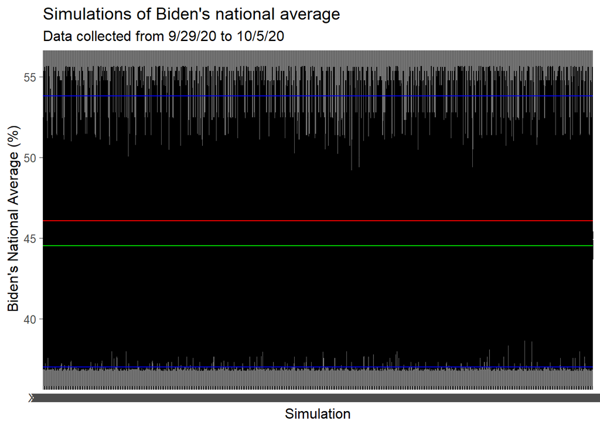

```r
#Here we will plot the mean incorporating CI infor with our
#ymin and ymax
biden_strap_plot<- ggplot(data = biden_straps,
                          mapping = aes(x = Sim,
                                        y = Mean,
                                        ymin = Lower_CI,
                                        ymax = Upper_CI))
#Set up a different theme
theme_set(theme_dark(base_size = 12))

#Here we will plot it so that each x value is a box plot of the #mean and the upper and lower CI
biden_strap_plot +

  geom_pointrange() +

  #Add the national average with a dashed line
  geom_hline(color = "red",
             yintercept = unlist(biden_avg)) +

  #Add the average of all bootstrapped means with a green        #line
  geom_hline(color = "green",
             yintercept = mean(biden_straps$Mean)) +

  #Add the average Upper CI as a dashed blue line
  geom_hline(color = "blue",
             yintercept = mean(biden_straps$Upper_CI)) +

  #Add the average Lower CI as a dashed blue line
  geom_hline(color = "blue",
             yintercept = mean(biden_straps$Lower_CI)) +

  #Label it
  labs(title = "Simulations of Biden's national average",
       subtitle = "Data collected from 9/29/20 to 10/5/20",
       x = "Simulation",
       y = "Biden's National Average (%)")
```

### 5d) What does this data mean?

However, because of the massive amount of data we are trying to describe here, the actual boxes are masked. To give a better idea of the values we are looking at I’ve included blue lines for the average upper and lower CIs, a red line that represents the national average from the original data, and a green line that represent the average of our simulated means

As we can see the bootstrapped mean 44.5428163 and the national average 46.0718522 are very close.

Additionally our SE of the bootstrapped mean 0.6564946 shows that our polling data is decently precise.

#### DISCLAIMER: There are some data points within our tidy’d up table from 4d that seem to heavily swing the data towards Trump (i.e., the results from Alabama show a 20% higher voting rate for Trump than Biden). Because the “national” data that we took here is only from a few states, not the whole nation, values that are that far away from the average can really swing our overall results

#### In this case we have an external viability issue because of how limited our data is!